# EFA: calificaciones de estudiantes

Jose M Sallan

## Datos de partida

Partimos de una matriz de correlación de calificaciones de estudiantes en seis materias:

```r
scores.cor <- matrix(c(
1.0,  0.439,    0.410,  0.288,  0.329,  0.248,
0.439,  1.0,    0.351,  0.354,  0.320,  0.329,
0.410,  0.351,  1.0,    0.164,  0.190,  0.181,
0.288,  0.354,  0.164,  1.0,    0.595,  0.470,
0.329,  0.320,  0.190,  0.595,  1.0,    0.464,
0.248,  0.329,  0.181,  0.470,  0.464,  1.0),
6,  6,  byrow="TRUE")

colnames(scores.cor) <- rownames(scores.cor) <- c("Gaélico", "Inglés", "Historia", "Aritmética", "Álgebra", "Geometría")
scores.cor
```

```
##            Gaélico Inglés Historia Aritmética Álgebra Geometría
## Gaélico      1.000  0.439    0.410      0.288   0.329     0.248
## Inglés       0.439  1.000    0.351      0.354   0.320     0.329
## Historia     0.410  0.351    1.000      0.164   0.190     0.181
## Aritmética   0.288  0.354    0.164      1.000   0.595     0.470
## Álgebra      0.329  0.320    0.190      0.595   1.000     0.464
## Geometría    0.248  0.329    0.181      0.470   0.464     1.000
```

## Análisis previos

Podemos comprobar que puede realizarse un análisis factorial exploratorio realizando el test de adecuación de la muestra de Kayser-Meyer-Olkin (KMO), y comprobando que la matriz de correlaciones de población no es la identidad mediante el test de esfericidad de Bartlett:

```r
library(psych)
KMO(scores.cor)
```

```
## Kaiser-Meyer-Olkin factor adequacy
## Call: KMO(r = scores.cor)
## Overall MSA =  0.77
## MSA for each item =
##    Gaélico     Inglés   Historia Aritmética    Álgebra  Geometría
##       0.77       0.81       0.76       0.74       0.75       0.83
```

```r
cortest.bartlett(scores.cor, n=150)
```

```
## $chisq
## [1] 210.1831
##
## $p.value
## [1] 1.798146e-36
##
## $df
## [1] 15
```

Los resultados del análisis indican que podemos llevar a cabo el análisis factorial.

Como análisis previo, podemos representar un correlograma de la matriz de correlaciones, que nos permite analizar visualmente los datos:

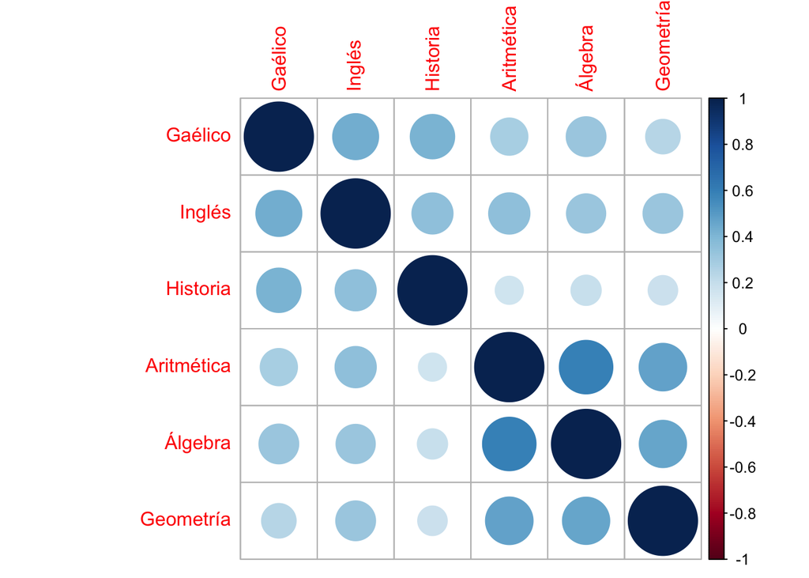

```r
library(corrplot)
corrplot(scores.cor, method="circle")
```

En esta matriz se aprecia una posible agrupación de las variables en dos factores: uno para asignaturas de “ciencias” (aritmética, álgebra, geometría) y de “letras” (gaélico, inglés, historia). Vamos a evaluar este posible modelo mediante un análisis factorial exploratorio extrayendo dos factores.

## Definición de los modelos

Definimos diversos modelos factoriales usando el paquete `psych`:

```r
library(psych)
pr.scores <- principal(r=scores.cor, nfactors=2)
pa.scores <- fa(r=scores.cor, nfactors=2, fm="pa")
ml.scores <- fa(r=scores.cor, nfactors=2, fm="ml")
```

## Resultados

Para analizar la naturaleza de los factores, veremos las cargas factoriales en cada factor. Consideraremos las que tengan un valor mayor que 0,4.

Las cargas factoriales para el modelo de componentes principales:

```r
print(pr.scores$loadings, cutoff=0.4)
```

```
##
## Loadings:
##            RC1    RC2
## Gaélico            0.765
## Inglés             0.661
## Historia           0.821
## Aritmética  0.833
## Álgebra     0.813
## Geometría   0.749
##
##                  RC1   RC2
## SS loadings    2.087 1.776
## Proportion Var 0.348 0.296
## Cumulative Var 0.348 0.644
```

Para el modelo de ejes principales:

```r
print(pa.scores$loadings, cutoff=0.4)
```

```
##
## Loadings:
##            PA1    PA2
## Gaélico            0.678
## Inglés             0.530
## Historia           0.646
## Aritmética  0.801
## Álgebra     0.742
## Geometría   0.573
##
##                  PA1   PA2
## SS loadings    1.563 1.165
## Proportion Var 0.261 0.194
## Cumulative Var 0.261 0.455
```

Y para el modelo de máxima verosimilitud:

```r
print(ml.scores$loadings, cutoff=0.4)
```

```
##
## Loadings:
##            ML1    ML2
## Gaélico            0.680
## Inglés             0.529
## Historia           0.646
## Aritmética  0.806
## Álgebra     0.739
## Geometría   0.570
##
##                  ML1   ML2
## SS loadings    1.563 1.167
## Proportion Var 0.261 0.194
## Cumulative Var 0.261 0.455
```

## Discusión de los resultados

Una vez examinados los resultados, podemos realizar una interpretación de los factores a partir de las variables con carga alta en cada factor:

- En los tres modelos, el análisis factorial exploratorio ha agrupado a las asignaturas de “ciencias” (aritmética, álgebra, geometría) en un factor, y a las de “letras” (gaélico, inglés, historia) en un segundo factor.
- La proporción de variabilidad de los datos explicada por este modelo es reducida: el 64,4% para el modelo de componentes principales y el 45,5% para los modelos de ejes principales y de máxima verosimilitud.